# Polynomial Regression

# Introduction

**Polynomial regression** is a tool that allows us to understand and predict the behavior of complex data. Unlike linear regression, which assumes a linear relationship between the independent and dependent variables, polynomial regression can model nonlinear relationships by incorporating polynomial terms.

First, we consider a univariate model:
$$\begin{equation}
y_i = f(x_i) + \varepsilon_i, \quad i = 1, \dotsc, n,
\end{equation}$$

In polynomial regression, $f$ is a polynomial function of degree $q$, expressed as:
$$\begin{equation*}
f(x) = \beta_0 + \beta_1 x + \beta_2 x^2 + \dots + \beta_q x^q
\end{equation*}$$
where $\beta_j$ are the coefficients for $j=0, \dotsc, q$. The model then can be represented as:
$$\begin{equation*}
y_i = \beta_0 + \beta_1 x_i + \beta_2 x_i^2 + \dots + \beta_q x_i^q +
\varepsilon_i, \quad i = 1, \dotsc, n.
\end{equation*}$$

The coefficients $\beta$ are estimated using linear regression, considering the model $y = X\beta + \varepsilon$, where $X = [1, x, x^2, \dotsc, x^q]$ and $\beta = [\beta_0, \beta_1, \beta_2, \dotsc \beta_q]^T$.

# Simulating data

For our examples, we will simulate data to explore how well polynomial regression can fit oscillating values.

```r
# Generate X values
x <- runif(300, min=0, max=1)
x <- x[order(x)]

# Error term
eps <- rnorm(300, mean=0, sd=0.05)

# True and observed Y values
y.true <- -x * cos(5 * (x + 0.5)^2) * (x - 1) +
          1.2 * exp(-(20^2) * (x - 0.5)^2) * (x - 1)^2
y.obs <- y.true + eps
```

To visualize the data, we utilize `ggplot2`:

```r
library(ggplot2)
```

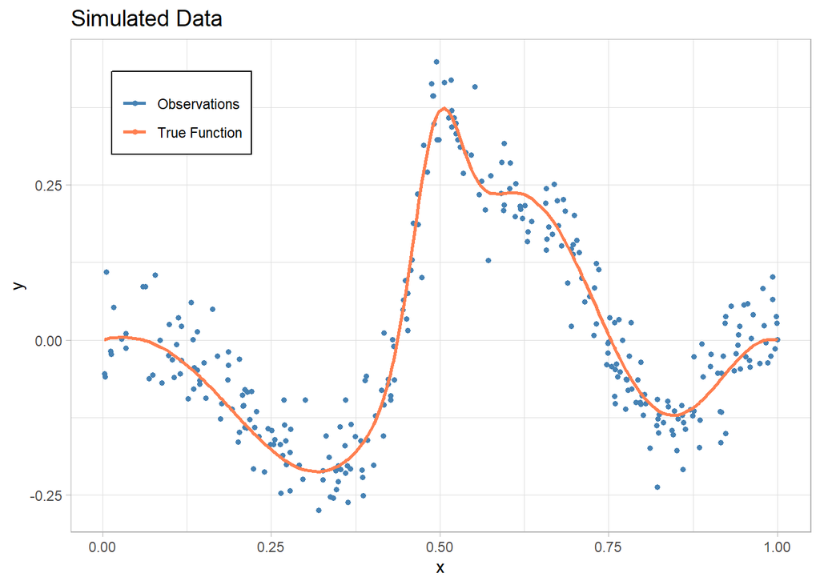

```r
data <- data.frame(x, y.obs, y.true)
ggplot(data = data) +
  geom_point(aes(x = x, y = y.obs, color = "Observations"),
             shape = 20, size = 2) +
  geom_path(aes(x = x, y = y.true, color = "True Function"), linewidth = 1) +
  scale_color_manual(values = c("Observations" = "steelblue",
                                "True Function" = "coral")) +
  labs(title = "Simulated Data",
       x = "x",
       y = "y",
       color = NULL) +
  theme_light() +
  theme(plot.title = element_text(size = 14),
        legend.position = c(0.15, 0.85),
        legend.background = element_rect(fill = "white",colour = "black"))
```

```r
# ggsave("graphs/PolynomialRegression.pdf", width = 10, height = 6, dpi = 300)
```

# Fitting the Data

We fit the data using the `lm` function from the `stats` package, starting with a polynomial of degree 8.

```r
polynomial <- lm(y.obs ~ poly(x, degree=8, raw=TRUE))
x.pred <- seq(-0.03, 1.12, length.out = 300)
y.pred <- predict(polynomial, newdata = data.frame(x = x.pred))
```

The results are displayed as follows:

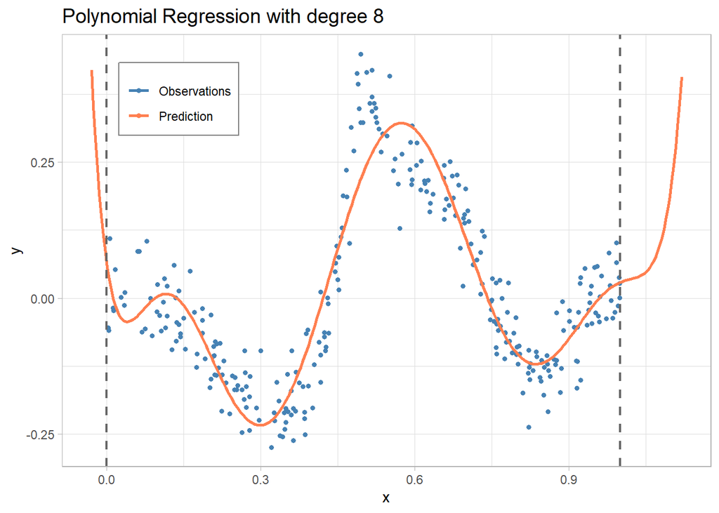

```r
data.polynomial <- data.frame(x, y.obs, x.pred, y.pred)
ggplot(data = data.polynomial) +
  geom_point(aes(x = x, y = y.obs, color = "Observations"),
             shape = 20, size = 2) +
  geom_path(aes(x = x.pred, y = y.pred, color = "Prediction"), linewidth = 1) +
  geom_vline(xintercept = 0, linetype = "dashed", color = "gray40",
             linewidth = 0.8) +
  geom_vline(xintercept = 1, linetype = "dashed", color = "gray40",
             linewidth = 0.8) +
  scale_color_manual(values = c("Observations" = "steelblue",
                                "Prediction" = "coral")) +
  labs(title = "Polynomial Regression with degree 8",
       x = "x",
       y = "y",
       color = NULL) +
  theme_light() +
  theme(plot.title = element_text(size = 14),
        legend.position = c(0.18, 0.85),
        legend.background = element_rect(fill = "white", colour = "gray50"))
```

```r
# ggsave("graphs/PolynomialRegression1.pdf", width = 10, height = 6, dpi = 300)
```

In this graph, we observe that the high degree allows the model to accurately fit the data within the variable $X$ range (in this case, $[0, 1]$). However, outside this range, the model predictions increase rapidly, which illustrates the potential risks of using high-degree polynomials without appropriate constraints. Now, we will explore the effects of using different polynomial degrees:

```r
poly.3  <- lm(y.obs ~ poly(x, degree=3, raw=TRUE))
poly.5  <- lm(y.obs ~ poly(x, degree=5, raw=TRUE))
poly.10 <- lm(y.obs ~ poly(x, degree=10, raw=TRUE))
poly.20 <- lm(y.obs ~ poly(x, degree=20, raw=TRUE))
```

We can examine the coefficients and other statistical details by using:

```r
summary(poly.3)
```

```
##
## Call:
## lm(formula = y.obs ~ poly(x, degree = 3, raw = TRUE))
##
## Residuals:
##      Min       1Q   Median       3Q      Max
## -0.29222 -0.12579 -0.00821  0.10024  0.40436
##
## Coefficients:
##                                  Estimate Std. Error t value Pr(>|t|)
## (Intercept)                      -0.02116    0.03963  -0.534  0.59378
## poly(x, degree = 3, raw = TRUE)1 -0.82190    0.31472  -2.612  0.00947 **
## poly(x, degree = 3, raw = TRUE)2  3.17293    0.69780   4.547 7.94e-06 ***
## poly(x, degree = 3, raw = TRUE)3 -2.50773    0.44678  -5.613 4.58e-08 ***
## ---
## Signif. codes:  0 '***' 0.001 '**' 0.01 '*' 0.05 '.' 0.1 ' ' 1
##
## Residual standard error: 0.1469 on 296 degrees of freedom
## Multiple R-squared:  0.1958, Adjusted R-squared:  0.1877
## F-statistic: 24.03 on 3 and 296 DF,  p-value: 6.059e-14
```

Next, we make predictions using these models:

```r
x.pred <- seq(min(x), max(x), length.out = 300)
y.pred3  <- predict(poly.3, newdata = data.frame(x = x.pred))
y.pred5  <- predict(poly.5, newdata = data.frame(x = x.pred))
y.pred10 <- predict(poly.10, newdata = data.frame(x = x.pred))
y.pred20 <- predict(poly.20, newdata = data.frame(x = x.pred))
```

The visualizations of these predictions are as follows:

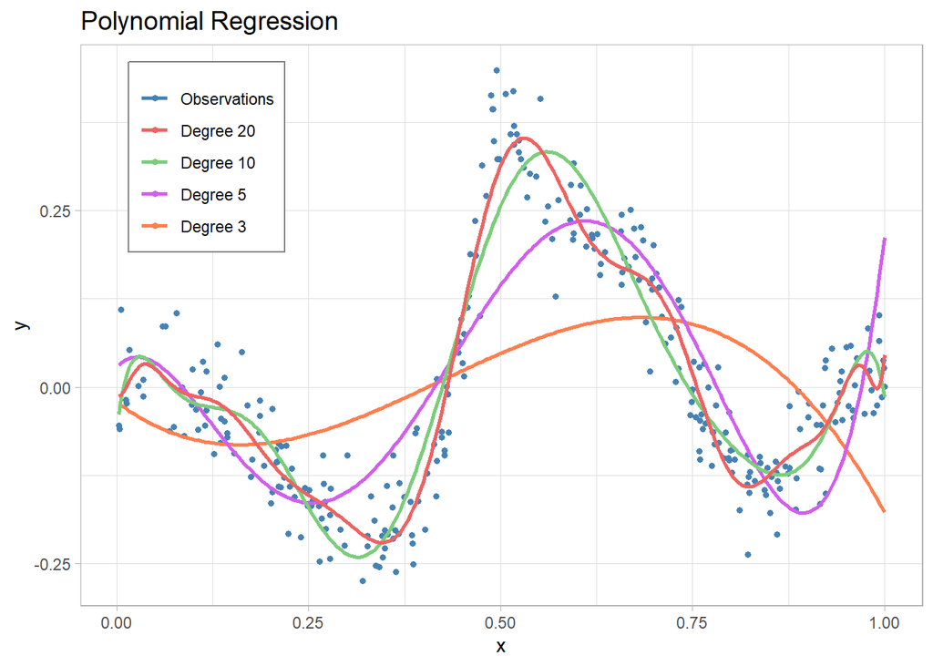

```r
data_pred <- data.frame(x, y.obs, x.pred, y.pred3, y.pred5, y.pred10, y.pred20)

ggplot(data = data_pred) +
  geom_point(aes(x = x, y = y.obs, color = "Observations"),
             shape = 20, size = 2) +
  geom_path(aes(x = x.pred, y=y.pred3, color = "Degree 3"), linewidth = 1) +
  geom_path(aes(x = x.pred, y=y.pred5, color = "Degree 5"), linewidth = 1) +
  geom_path(aes(x = x.pred, y=y.pred10, color = "Degree 10"), linewidth = 1) +
  geom_path(aes(x = x.pred, y=y.pred20, color = "Degree 20"), linewidth = 1) +
  scale_color_manual(values = c("Observations"="steelblue",
                                "Degree 3"="coral",
                                "Degree 5"="mediumorchid2",
                                "Degree 10"="palegreen3",
                                "Degree 20"="indianred2"),
                     limits = c("Observations", "Degree 20", "Degree 10",
                                "Degree 5", "Degree 3")) +
  labs(title = "Polynomial Regression",
       x = "x",
       y = "y",
       color = NULL) +
  theme_light() +
  theme(plot.title = element_text(size = 14),
        legend.position = c(0.15, 0.8),
        legend.background = element_rect(fill = "white", colour = "gray50"))
```

```r
# ggsave("graphs/PolynomialRegression2.pdf", width = 10, height = 6, dpi = 300)
```

The graphs shows that ,as the degree of the polynomial increases, the curve fits more closely to fluctuations in the data. However, this also increases the risk of overfitting, so when using polynomial regression, it is crucial to correctly choose the degree of the polynomial.